# Exploring the dynamics of dyadic conversations using categorical cross-recurrence quantification analysis

By: Shirley Duong

Last updated: 03/05/24

This document contains a tutorial on categorical cross-recurrence quantification analysis (CRQA) using the [‘crqa’ package](https://cran.r-project.org/web/packages/crqa/crqa.pdf) ([Coco et al., 2021](https://journal.r-project.org/archive/2021/RJ-2021-062/RJ-2021-062.pdf)) as part of the paper, [“Exploring dynamic structures of dyadic conversations using categorical cross recurrence quantification analysis: A tutorial” by Duong, Davis, Bachman, Votruba-Drzal, and Libertus (2024)](https://www.tqmp.org/RegularArticles/vol20-2/p121/p121.pdf).

Utterance-level data of caregiver-child conversations involving number- and math-related conversations (i.e., number talk) were used as examples. A total of four dyads were chosen as examples. One pair of dyads (`ID` = “Dyad1”, “Dyad2”) has similar frequencies of total number talk, but different values on the recurrence metrics. Another pair of dyads (`ID` = “Dyad3”, “Dyad4”) has similar recurrence rates and different values on other recurrence metrics.

# 1 Import libraries

```r
# data manipulation, plotting
library(tidyverse)
library(reshape) # for melting data to generate recurrence plots
# descriptives
library(psych)
# displays
library(knitr)

# recurrence analysis
library(crqa)

# function writing
library(lazyeval)
```

# 2 Set-up data

Import data.

```r
d <- read.csv("Transcription_Data_Tutorial.csv")
```

This dataframe contains utterance-level data from caregiver-child conversations involving number talk. The caregiver will be referred to as “parent” moving forward.

Variable descriptions:

- `ID`: Dyad identifier
- `timepoint`: The order in which the parent or child utterance appeared in the conversation; takes on values of 1 to the total number of utterances spoken in each interaction
- `speaker`: The person who uttered (**p** = *parent*, **c** = *child*)
- `number_talk`: Whether number talk occurred in the corresponding utterance (0 = **no**, 1 = **yes**)
- `transcript`: Speech content

```r
glimpse(d)
```

```
## Rows: 1,180
## Columns: 5
## $ ID          <chr> "Dyad1", "Dyad1", "Dyad1", "Dyad1", "Dyad1", "Dyad1", "Dya…
## $ timepoint   <int> 1, 2, 3, 4, 5, 6, 7, 8, 9, 10, 11, 12, 13, 14, 15, 16, 17,…
## $ speaker     <chr> "p", "p", "p", "p", "p", "c", "p", "p", "c", "c", "p", "c"…
## $ number_talk <int> 0, 0, 0, 0, 0, 0, 0, 0, 0, 0, 0, 0, 0, 0, 0, 0, 0, 0, 0, 0…
## $ transcript  <chr> "Wolfie", "no no", "we're gonna play with these toys", "Wo…
```

Recode data into event states for the parent and child.

- 1 = **number talk by either speaker**
- 2 = **no utterance by either speaker during number talk of the other speaker**
- 3 = **caregiver non-number talk**
- 4 = **child non-number talk**
- 5 = **no utterance by the caregiver during non-number talk of the child**
- 6 = **no utterance by the child during non-number talk of the caregiver**

The `parent_data` variable can take on codes 1, 2, 3, and 5. The `child_data` variable can take on codes 1, 2, 4, and 6. Since the primary event of interest was number talk and CRQA is concerned with when events co-occur, we force non-recurrence for other types of talk. This is why caregiver non-number talk is given a different code than child non-number talk.

```r
d <- d %>%
  mutate(parent_data = ifelse(speaker == "p" & number_talk == 1, 1,
                               ifelse(speaker == "p" & number_talk == 0, 3,
                                      ifelse(speaker == "c" & number_talk == 1, 2, 5))),
         child_data = ifelse(parent_data == 1, 2,
                           ifelse(parent_data == 3, 6,
                                  ifelse(parent_data == 5, 4, 1)))
         )
```

# 3 Obtain descriptives

Calculate frequencies of talk.

```r
d_summary <- d %>%
  group_by(ID, speaker) %>%
  summarise(utterances = max(1:n()),
            number_talk = sum(number_talk)
            ) %>%
  pivot_wider(id_cols = "ID",
              values_from = c("utterances", "number_talk"),
              names_from = "speaker") %>%
  mutate(utterances_total = utterances_c + utterances_p,
         number_talk_total = number_talk_c + number_talk_p)
```

[output not shown]

Show frequencies of talk in example interactions.

```r
d_summary %>%
  select(ID, # rearrange columns
         utterances_c, utterances_p, utterances_total,
         number_talk_c, number_talk_p, number_talk_total)
```

```
## # A tibble: 4 × 7
## # Groups:   ID [4]
##   ID    utterances_c utterances_p utterances_total number_talk_c number_talk_p
##   <chr>        <int>        <int>            <int>         <int>         <int>
## 1 Dyad1          163          149              312            53            29
## 2 Dyad2          113          209              322            19            67
## 3 Dyad3          120          144              264            17            38
## 4 Dyad4          102          180              282            38            17
## # ℹ 1 more variable: number_talk_total <int>
```

# 4 Set CRQA hyperparameters

Specify hyperparameters. For this tutorial, we use a radius (`radius` argument in `crqa()`) of .5, a delay (`delay`) of 0, and an embedded dimension (`embed`) of 1.

```r
radius_value = .5
delay_value = 0
embedding_value = 1
```

Specify minimum diagonal and vertical length of recurrent points.

```r
min_diag = 2
min_vert = 2
```

# 5 Apply CRQA

Recurrence metrics:

- **Recurrence rate** (`RR`): Percentage of recurrent points in a RP. How often is number talk co-occurring? What is the extent to which dyads are aligned in using number talk?
- **Determinism** (`DET`): Percentage of recurrent points that form diagonal lines. How often do speakers follow each others’ number utterances or engage in “back and forth” exchanges of number talk?
- **Average diagonal line** (`meanL`) - Mean length of diagonal lines or number exchanges.
- **Laminarity** (`LAM`) – Percentage of recurrent points that form vertical (or horizontal, since we forced non-recurrence) lines. How often does one speaker use consecutive number utterances after the other person introduces or uses number talk?
- **Trapping time** (`TT`) - Average length of vertical lines.

Use the `crqa()` function to obtain recurrence plots and metrics. Since this tutorial uses a dataset with multiple dyads, the data need to be subset to only include the dyad of interest. If you only have one dyad and two vectors, say `toy_parent` and `toy_child`, then you can simply write `crqa(toy_parent, toy_child)` and run the function (see below for this example).

### 5.0.1 Toy example

```r
# parent and child data series
toy_parent <- c(3, 2, 1, 1, 2, 1, 3, 5, 1, 2, 1, 1, 5, 1, 1)
toy_child <- c(6, 1, 2, 2, 1, 2, 6, 4, 2, 1, 2, 2, 4, 2, 2)

# run crqa
example_crqa <- crqa(toy_parent,
                     toy_child,
                     radius = radius_value,
                     delay = delay_value,
                     embed = embedding_value,
                     mindiagline = min_diag,
                     minvertline = min_vert
                     )

# show output
example_crqa
```

```
## $RR
## [1] 21.33333
##
## $DET
## [1] 50
##
## $NRLINE
## [1] 12
##
## $maxL
## [1] 2
##
## $L
## [1] 2
##
## $ENTR
## [1] 0
##
## $rENTR
## [1] NaN
##
## $LAM
## [1] 37.5
##
## $TT
## [1] 2
##
## $catH
## [1] NA
##
## $RP
## 15 x 15 sparse Matrix of class "ngCMatrix"
##
##  [1,] . . . . . . . . . . . . . . .
##  [2,] . . | | . | . . | . | | . | |
##  [3,] . | . . | . . . . | . . . . .
##  [4,] . | . . | . . . . | . . . . .
##  [5,] . . | | . | . . | . | | . | |
##  [6,] . | . . | . . . . | . . . . .
##  [7,] . . . . . . . . . . . . . . .
##  [8,] . . . . . . . . . . . . . . .
##  [9,] . | . . | . . . . | . . . . .
## [10,] . . | | . | . . | . | | . | |
## [11,] . | . . | . . . . | . . . . .
## [12,] . | . . | . . . . | . . . . .
## [13,] . . . . . . . . . . . . . . .
## [14,] . | . . | . . . . | . . . . .
## [15,] . | . . | . . . . | . . . . .
```

### 5.0.2 Example dyad 1

```r
crqa(d[d$ID == "Dyad1",]$parent_data, # base R way
     d[d$ID == "Dyad1",]$child_data)
```

```
## $RR
## [1] 3.157873
##
## $DET
## [1] 24.78855
##
## $NRLINE
## [1] 352
##
## $maxL
## [1] 5
##
## $L
## [1] 2.164773
##
```

[output cut: 2834 more lines]

### 5.0.3 Example dyad 2

```r
crqa(d %>% filter(ID == "Dyad2") %>% select(parent_data), # dplyr way
     d %>% filter(ID == "Dyad2") %>% select(child_data))
```

```
## $RR
## [1] 2.455538
##
## $DET
## [1] 37.86332
##
## $NRLINE
## [1] 454
##
## $maxL
## [1] 4
##
## $L
## [1] 2.123348
##
```

[output cut: 343 more lines]

### 5.0.4 Example dyad 3

```r
crqa(d %>% filter(ID == "Dyad3") %>% select(parent_data),
     d %>% filter(ID == "Dyad3") %>% select(child_data))
```

```
## $RR
## [1] 1.853765
##
## $DET
## [1] 40.86687
##
## $NRLINE
## [1] 248
##
## $maxL
## [1] 4
##
## $L
## [1] 2.129032
##
```

[output cut: 2137 more lines]

### 5.0.5 Example dyad 4

```r
crqa(d %>% filter(ID == "Dyad4") %>% select(parent_data),
     d %>% filter(ID == "Dyad4") %>% select(child_data))
```

```
## $RR
## [1] 1.624667
##
## $DET
## [1] 27.24458
##
## $NRLINE
## [1] 168
##
## $maxL
## [1] 3
##
## $L
## [1] 2.095238
##
```

[output cut: 2281 more lines]

# 6 Obtain RPs

## 6.1 Using `crqa()`)

Use the `$` operator to extract the `RP`. This is large and hard to read.

```r
crqa(d %>% filter(ID == "Dyad1") %>% select(parent_data),
     d %>% filter(ID == "Dyad1") %>% select(child_data))$RP
```

```
## 312 x 312 sparse Matrix of class "ngCMatrix"
##
##   [1,] . . . . . . . . . . . . . . . . . . . . . . . . . . . . . . . . . . . .
##   [2,] . . . . . . . . . . . . . . . . . . . . . . . . . . . . . . . . . . . .
##   [3,] . . . . . . . . . . . . . . . . . . . . . . . . . . . . . . . . . . . .
##   [4,] . . . . . . . . . . . . . . . . . . . . . . . . . . . . . . . . . . . .
##   [5,] . . . . . . . . . . . . . . . . . . . . . . . . . . . . . . . . . . . .
##   [6,] . . . . . . . . . . . . . . . . . . . . . . . . . . . . . . . . . . . .
##   [7,] . . . . . . . . . . . . . . . . . . . . . . . . . . . . . . . . . . . .
##   [8,] . . . . . . . . . . . . . . . . . . . . . . . . . . . . . . . . . . . .
##   [9,] . . . . . . . . . . . . . . . . . . . . . . . . . . . . . . . . . . . .
##  [10,] . . . . . . . . . . . . . . . . . . . . . . . . . . . . . . . . . . . .
##  [11,] . . . . . . . . . . . . . . . . . . . . . . . . . . . . . . . . . . . .
##  [12,] . . . . . . . . . . . . . . . . . . . . . . . . . . . . . . . . . . . .
##  [13,] . . . . . . . . . . . . . . . . . . . . . . . . . . . . . . . . . . . .
```

[output cut: 2803 more lines]

## 6.2 Using `ggplot()`

Transform the sparse matrices generated from the `crqa()` function into more visually appealing RPs.

### 6.2.1 Toy example

Generate the RP of the example data to show the process and output.

First, extract the RP from the example and reshape the data so that there are 3 columns: the parent data series, the child data series, and `value` which indicates whether each pair of parent-child utterances is a recurrent point. Also, the number of rows should equal the square of the length of the data series. In this case, it’s 15 squared or 225.

```r
# extract RP from the crqa output
recurrence_matrix <- melt(as.matrix(example_crqa$RP),
                          varnames = c("toy_child", "toy_parent"))

recurrence_matrix %>% glimpse()
```

```
## Rows: 225
## Columns: 3
## $ toy_child  <int> 1, 2, 3, 4, 5, 6, 7, 8, 9, 10, 11, 12, 13, 14, 15, 1, 2, 3,…
## $ toy_parent <int> 1, 1, 1, 1, 1, 1, 1, 1, 1, 1, 1, 1, 1, 1, 1, 2, 2, 2, 2, 2,…
## $ value      <lgl> FALSE, FALSE, FALSE, FALSE, FALSE, FALSE, FALSE, FALSE, FAL…
```

Then, use ggplot’s `geom_raster()` to generate the RP (showing the *recurrence* of number talk).

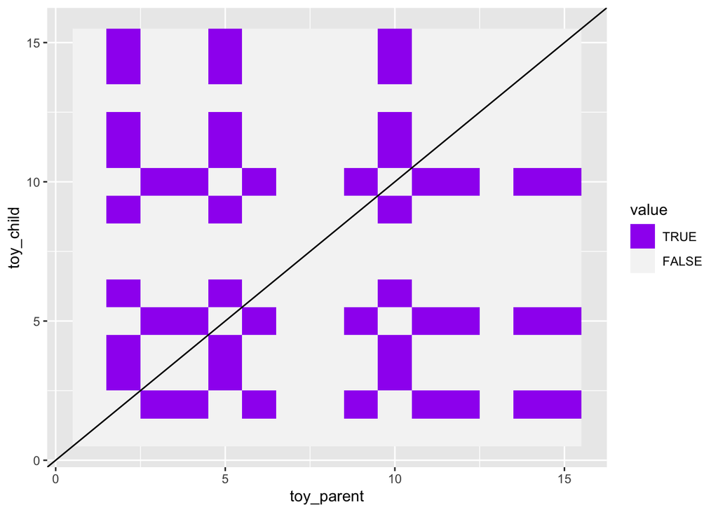

```r
recurrence_plot <- recurrence_matrix %>%
  ggplot(mapping = aes(x = toy_parent,
                       y = toy_child,
                       fill = value)
         ) +
  geom_raster() +
  scale_fill_manual(values=c("purple", # purple for recurrent points
                             "#F5F5F5"), # gray for non-recurrence points
                    breaks=c(TRUE, FALSE)) +
  geom_abline(intercept = 0, slope = 1) # add line of incidence

# show plot
recurrence_plot
```

Generate the data for the rugs (showing the *occurrence* of number talk for each speaker) and then add to the RP.

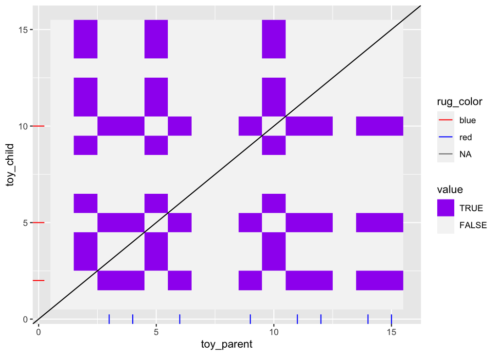

```r
# first combine data series into a data frame
plot_data <- cbind(toy_parent, toy_child) %>%
  as.data.frame() %>%
  rowid_to_column("utterance_order") %>%
  mutate(x_binary = ifelse(toy_parent == 1, utterance_order, NA), # NA to ensure no rug mark appears when number talk is *not* being used
         y_binary = ifelse(toy_child == 1, utterance_order, NA)
         ) %>%
  # add rug colors for each speaker
  mutate(rug_color = ifelse(!is.na(x_binary) & is.na(y_binary), "red", # child
                            ifelse(!is.na(y_binary) & is.na(x_binary), "blue", NA) # parent
                            )
         )

# add rugs to the axes
recurrence_plot <- recurrence_plot +
  geom_rug(inherit.aes = FALSE, # ensure that the mapping from above does not get combined
           data = plot_data,
           mapping = aes(x = x_binary,
                         y = y_binary,
                         color = rug_color)) +
  scale_color_manual(values=c("red", # red for child
                              "blue")) # blue for parent

# show plot
recurrence_plot
```

Adjust the RP aesthetics and display the plot.

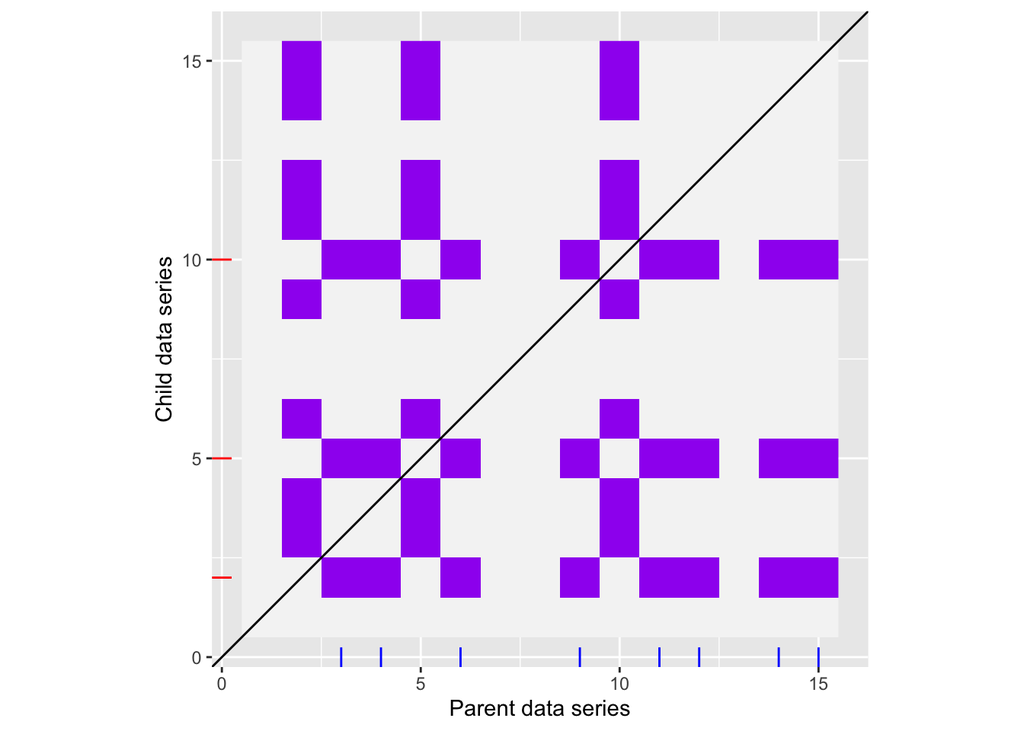

```r
recurrence_plot <- recurrence_plot +
  # adjust RP aesthetics
  theme(axis.line = element_blank(), # remove axis lines/tick marks
        legend.position = "none") +  # remove legend
  coord_equal() + # make square
  labs(x = "Parent data series", y = "Child data series") # add axis labels

# show plot
recurrence_plot
```

**Reading the RPs**:

- The parent data series is plotted along the x-axis and the child data series is plotted along the y-axis.
- The blue (parent) and red (child) rug marks (thin lines) along the axes represent whether a number utterance occurred at a particular point in time. This can be summarized to show the *frequency* of number talk.
- The purple areas on the plot represent when number talk co-occurred. This can be summarized to show the *alignment* in or *reciprocity* of number talk.
- The black diagonal line is the line of incidence, which reflects when talk occurs at the same moment in time. In our case of conversational exchanges, recurrence along this line is not present, so this appears on the plot just for reference.

### 6.2.2 Create RP function

Create a function for multiple use. This function takes in data from multiple dyads and subsets to the `chosen_dyad`. This function assumes that the hyperparameters were already set.

Also, if there is no recurrence (i.e., RR = 0), then the `crqa()` function returns a “logical” class of `RP`. Thus, this function also generates an appropriate plot for when there RR = 0.

```r
make_recurrence_plot <- function(data, chosen_dyad){

  # subset data
  d_use <- data %>% filter(ID == chosen_dyad)

  # run crqa
  crqa_output <- crqa(d_use$parent_data,
                      d_use$child_data,
                      radius = radius_value,
                      delay = delay_value,
                      embed = embedding_value,
                      mindiagline = min_diag,
                      minvertline = min_vert)

  # extract recurrence plot from crqa output
  if(class(crqa_output$RP) == "logical"){ # if RR = 0...

    # the crqa() function does not supply an RP if there is no recurrence
    # in these cases, the class of $RP is "logical", not a matrix
    # so we need to supply a matrix for these cases
    # the matrix needs to have the same dimensions as the total number of utterances in the conversation

    child_data_zeroRR <- c(1:nrow(d_use))
    parent_data_zero_RR <- c(1:nrow(d_use))

    # generate all possible combinations of time points
    recurrence_matrix <- expand.grid(child_data_zeroRR, parent_data_zero_RR) %>%
      as.data.frame() %>%
      mutate(value = FALSE) %>% # specify no recurrence at all pairs of time points
      dplyr::rename(child_data = Var1,
                    parent_data = Var2)

  } else {
    # else use the RP provided by crqa() and reshape data
    recurrence_matrix <- melt(as.matrix(crqa_output$RP),
                          varnames = c("child_data", "parent_data"))

  }


  # generate rp using geom_raster()
  recurrence_plot <- recurrence_matrix %>%
  ggplot(mapping = aes(x = parent_data,
                       y = child_data,
                       fill = value)
         ) +
  geom_raster() +
  scale_fill_manual(values=c("#a269db", # purple for recurrent points
                             "#F5F5F5"), # gray for non-recurrence points
                    breaks=c(TRUE, FALSE)) +
  geom_abline(intercept = 0, slope = 1) # add line of incidence

  # add rugs
  plot_data <- cbind(d_use$parent_data, d_use$child_data) %>%
  as.data.frame() %>%
  rowid_to_column("utterance_order") %>%
  mutate(x_binary = ifelse(V1 == 1, utterance_order, NA), # NA to ensure no rug mark appears when number talk is *not* being used
         y_binary = ifelse(V2 == 1, utterance_order, NA)
         ) %>%
  # add rug colors for each speaker
  mutate(rug_color = ifelse(!is.na(x_binary) & is.na(y_binary), "red", # child
                            ifelse(!is.na(y_binary) & is.na(x_binary), "blue", # parent
                                   NA)
                            )
         )

  recurrence_plot <- recurrence_plot +
    geom_rug(inherit.aes = FALSE, # ensure that the mapping from above does not get combined
             data = plot_data,
             mapping = aes(x = as.numeric(x_binary),
                           y = as.numeric(y_binary),
                           color = as.character(rug_color))) +
    scale_color_manual(values=c("red", # red for child
                                "blue")) # blue for parent

  # adjust rp aesthetics
  recurrence_plot <- recurrence_plot +
  # adjust RP aesthetics
    theme(axis.line = element_blank(), # remove axis lines/tick marks
        legend.position = "none") +  # remove legend
    coord_equal() + # make square
    labs(x = "Parent data series", y = "Child data series") # add axis labels

  # show plot
  recurrence_plot
}
```

### 6.2.3 Example dyad 1

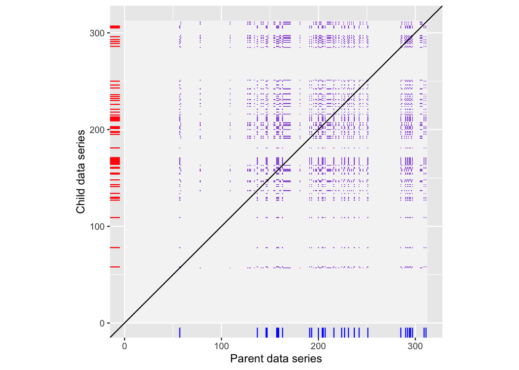

```r
make_recurrence_plot(d, "Dyad1")
```

### 6.2.4 Example dyad 2

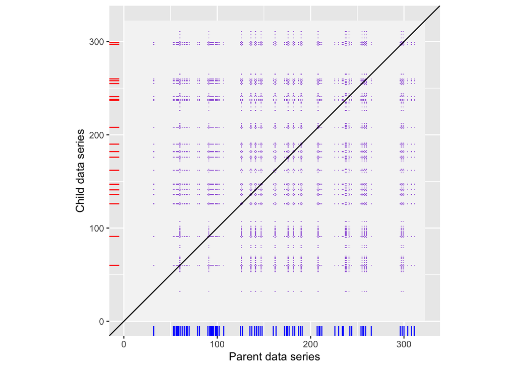

```r
make_recurrence_plot(d, "Dyad2")
```

### 6.2.5 Example dyad 3

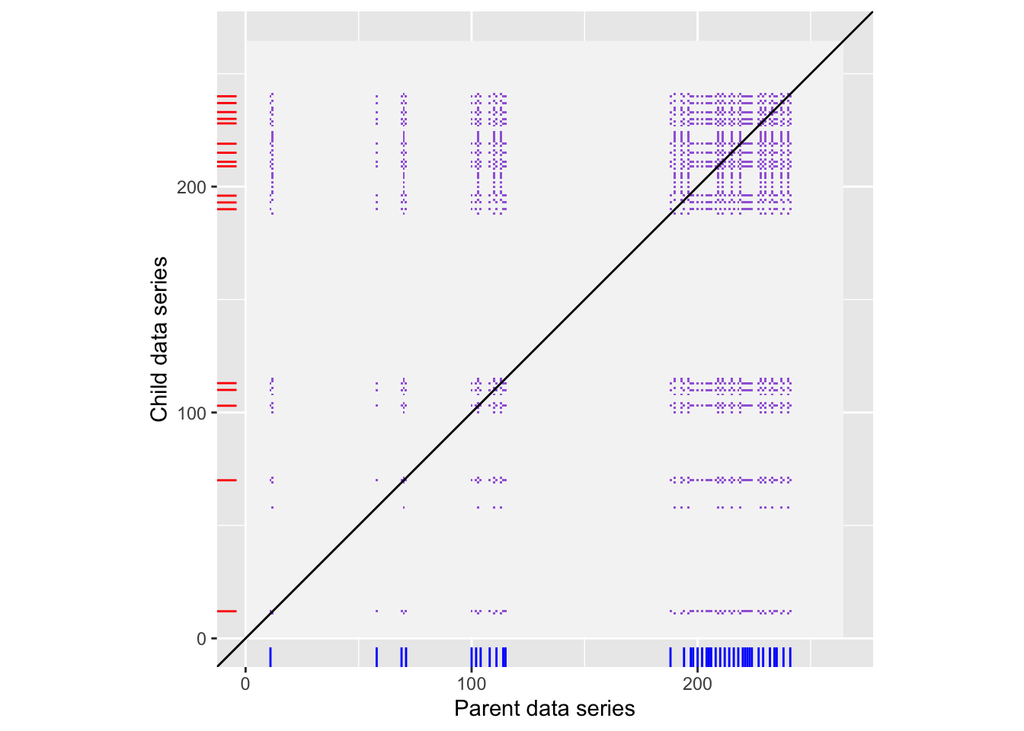

```r
make_recurrence_plot(d, "Dyad3")
```

### 6.2.6 Example dyad 4

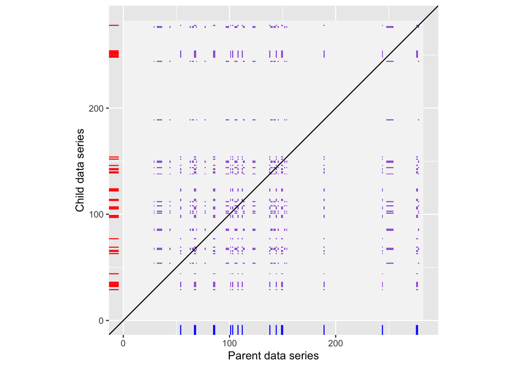

```r
make_recurrence_plot(d, "Dyad4")
```

### 6.2.7 Example with RR=0

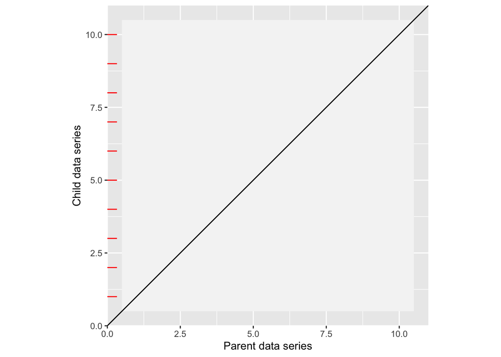

```r
# generate data where only one speaker (the child in this example) employs the event of interest
child_data <- rep(1, 10)
parent_data <- rep(2, 10)
ID <- rep("Dyad RR0", 10)
d_rr0 <- cbind(ID, child_data, parent_data) %>% as.data.frame()

# generate RP that is blank since RR = 0
make_recurrence_plot(d_rr0, "Dyad RR0")
```